# Time Series Linear Model (TSLM): NYC Motor Vehicle Collisions

2026-11-16

## R Markdown

#1. Introduction

This project examines daily motor vehicle collisions in New York City using time-series analysis and forecasting techniques. The objective is to identify long-term trends, weekly and annual seasonal patterns, and changes in collision frequency.

The analysis evaluates Seasonal Naïve, Exponential Smoothing (ETS), Autoregressive Integrated Moving Average (ARIMA), ARIMA with explanatory variables (ARIMAX), and Time Series Linear Models (TSLM).

Forecast performance is evaluated using a chronological training and testing design. Observations from 2012 through 2024 are used for model estimation, while 2025 is reserved for out-of-sample evaluation.

#2. Data Preparation and Data Quality #2.1 Load Required Libraries

```r
library(tidyverse)
library(fpp3)
library(lubridate)
library(scales)
library(patchwork)
```

#2.2 Import the Dataset

```r
library(janitor)
crashes <- readr::read_csv(
  "C:/Users/newer/OneDrive/Desktop/ADS 506/Final Assignment/data/Motor_Vehicle_Collisions_-_Crashes_20261114.csv",
  show_col_types = FALSE
) |>
  clean_names()

glimpse(crashes)
```

```
## Rows: 2,305,424
## Columns: 29
## $ crash_date                    <chr> "11/11/2026", "11/11/2026", "11/11/2026"…
## $ crash_time                    <time> 11:20:00, 12:15:00, 13:30:00, 17:35:00,…
## $ borough                       <chr> "QUEENS", "BRONX", "QUEENS", "QUEENS", "…
## $ zip_code                      <dbl> NA, 10460, NA, NA, NA, NA, 10039, 11206,…
## $ latitude                      <dbl> 40.69311, 40.84094, 40.76536, 40.71874, …
## $ longitude                     <dbl> -73.81976, -73.87919, -73.80236, -73.789…
## $ location                      <chr> "(40.693115, -73.81976)", "(40.84094, -7…
## $ on_street_name                <chr> "127 ST", NA, "163 ST", NA, "DUMONT AVE"…
## $ cross_street_name             <chr> NA, "2044 BOSTON RD", NA, "175-48 GRAND …
## $ off_street_name               <chr> NA, NA, "35 AVE", NA, "SARATOGA AVE", NA…
## $ number_of_persons_injured     <dbl> 1, 0, 0, 0, 1, 0, 1, 2, 3, 0, 1, 0, 1, 1…
## $ number_of_persons_killed      <dbl> 0, 0, 0, 0, 0, 0, 0, 0, 0, 0, 0, 0, 0, 0…
## $ number_of_pedestrians_injured <dbl> 0, 0, 0, 0, 1, 0, 0, 0, 0, 0, 0, 0, 0, 0…
```

[output cut: 16 more lines]

```r
names(crashes)
```

```
##  [1] "crash_date"                    "crash_time"
##  [3] "borough"                       "zip_code"
##  [5] "latitude"                      "longitude"
##  [7] "location"                      "on_street_name"
##  [9] "cross_street_name"             "off_street_name"
## [11] "number_of_persons_injured"     "number_of_persons_killed"
## [13] "number_of_pedestrians_injured" "number_of_pedestrians_killed"
## [15] "number_of_cyclist_injured"     "number_of_cyclist_killed"
## [17] "number_of_motorist_injured"    "number_of_motorist_killed"
## [19] "contributing_factor_vehicle_1" "contributing_factor_vehicle_2"
## [21] "contributing_factor_vehicle_3" "contributing_factor_vehicle_4"
## [23] "contributing_factor_vehicle_5" "collision_id"
## [25] "vehicle_type_code_1"           "vehicle_type_code_2"
## [27] "vehicle_type_code_3"           "vehicle_type_code_4"
## [29] "vehicle_type_code_5"
```

#2.3 Convert Dates and Prepare Daily Observations

Each row represents an individual collision. The records are aggregated into daily collision counts.

```r
# STEP 1: Convert crash dates
crashes <- crashes |>
  mutate(
    day = lubridate::mdy(crash_date)
  ) |>
  filter(!is.na(day))

# STEP 2: Aggregate daily collision counts
crash_ts <- crashes |>
  count(day, name = "crashes") |>
  as_tsibble(index = day) |>
  fill_gaps(.full = TRUE) |>
  mutate(
    crashes = replace_na(crashes, 0)
  )

# STEP 3: Inspect dataset
glimpse(crash_ts)
```

```
## Rows: 5,247
## Columns: 2
## $ day     <date> 2012-07-01, 2012-07-02, 2012-07-03, 2012-07-04, 2012-07-05, 2…
## $ crashes <int> 538, 564, 664, 432, 591, 638, 490, 464, 533, 524, 565, 577, 60…
```

```r
# STEP 4: Check date range
range(crash_ts$day)
```

```
## [1] "2012-07-01" "2026-11-11"
```

```r
# STEP 5: Count observations
nrow(crash_ts)
```

```
## [1] 5247
```

```r
# STEP 6: Check missing values
sum(is.na(crash_ts$crashes))
```

```
## [1] 0
```

```r
# STEP 7: Check duplicate dates
anyDuplicated(crash_ts$day)
```

```
## [1] 0
```

The daily time series is constructed by counting collision records for each date. Missing calendar dates are included in the time index and assigned zero recorded collisions

#2.4 Exploratory Time-Series Plot

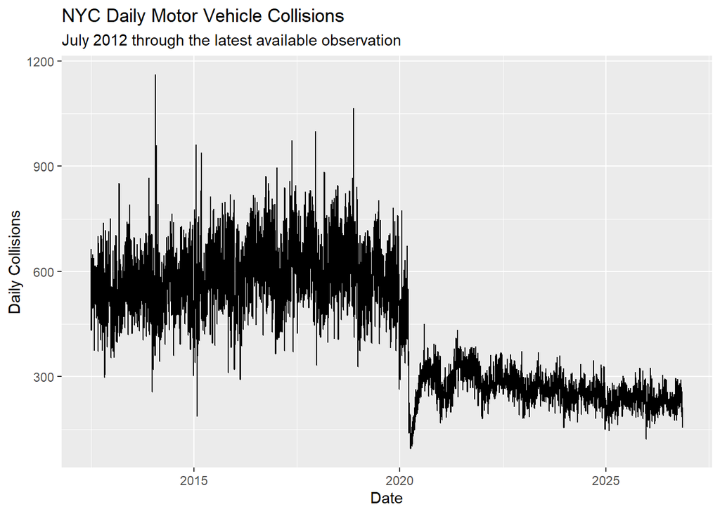

```r
crash_ts |>
  autoplot(crashes) +
  labs(
    title = "NYC Daily Motor Vehicle Collisions",
    subtitle = "July 2012 through the latest available observation",
    x = "Date",
    y = "Daily Collisions"
  )
```

#2.5 Descriptive Statistics

```r
crash_ts |>
  as_tibble() |>
  summarise(
    observations = n(),
    average_crashes = mean(crashes),
    median_crashes = median(crashes),
    standard_deviation = sd(crashes),
    minimum_crashes = min(crashes),
    maximum_crashes = max(crashes)
  )
```

```
## # A tibble: 1 × 6
##   observations average_crashes median_crashes standard_deviation minimum_crashes
##          <int>           <dbl>          <int>              <dbl>           <int>
## 1         5247            439.            441               183.              94
## # ℹ 1 more variable: maximum_crashes <int>
```

The chronological split prevents future observations from being used during model estimation.

```r
train <- crash_ts |>
  filter_index("2012-01-01" ~ "2024-12-31") |>
  mutate(
    trend = row_number(),
    weekday = factor(
      wday(day),
      levels = 1:7,
      labels = c(
        "Sunday", "Monday", "Tuesday",
        "Wednesday", "Thursday", "Friday",
        "Saturday"
      )
    )
  )

test <- crash_ts |>
  filter_index("2025-01-01" ~ "2025-12-31") |>
  mutate(
    trend = row_number() + nrow(train),
    weekday = factor(
      wday(day),
      levels = 1:7,
      labels = c(
        "Sunday", "Monday", "Tuesday",
        "Wednesday", "Thursday", "Friday",
        "Saturday"
      )
    )
  )

# Verify observations
nrow(train)
```

```
## [1] 4567
```

```r
nrow(test)
```

```
## [1] 365
```

```r
range(train$day)
```

```
## [1] "2012-07-01" "2024-12-31"
```

```r
range(test$day)
```

```
## [1] "2025-01-01" "2025-12-31"
```

```r
# Check weekday distribution
table(train$weekday)
```

```
##
##    Sunday    Monday   Tuesday Wednesday  Thursday    Friday  Saturday
##       653       653       653       652       652       652       652
```

```r
table(test$weekday)
```

```
##
##    Sunday    Monday   Tuesday Wednesday  Thursday    Friday  Saturday
##        52        52        52        53        52        52        52
```

```r
# Confirm complete testing period
stopifnot(nrow(test) == 365)
```

The trend variable provides a continuous sequential index across the training and testing periods. The weekday variable identifies recurring weekly patterns.

# Daily Collision Time Series

```r
crash_ts <- crashes |>
  count(day, name = "crashes") |>
  as_tsibble(index = day) |>
  fill_gaps(.full = TRUE) |>
  mutate(
    crashes = replace_na(crashes, 0)
  )

# Inspect dataset
glimpse(crash_ts)
```

```
## Rows: 5,247
## Columns: 2
## $ day     <date> 2012-07-01, 2012-07-02, 2012-07-03, 2012-07-04, 2012-07-05, 2…
## $ crashes <int> 538, 564, 664, 432, 591, 638, 490, 464, 533, 524, 565, 577, 60…
```

```r
# Date range
range(crash_ts$day)
```

```
## [1] "2012-07-01" "2026-11-11"
```

```r
# Number of daily observations
nrow(crash_ts)
```

```
## [1] 5247
```

```r
# Check missing values
sum(is.na(crash_ts$crashes))
```

```
## [1] 0
```

```r
# Check duplicate dates
anyDuplicated(crash_ts$day)
```

```
## [1] 0
```

#4. Exploratory Analysis of Weekly Patterns #4.1 Average Collisions by Weekday

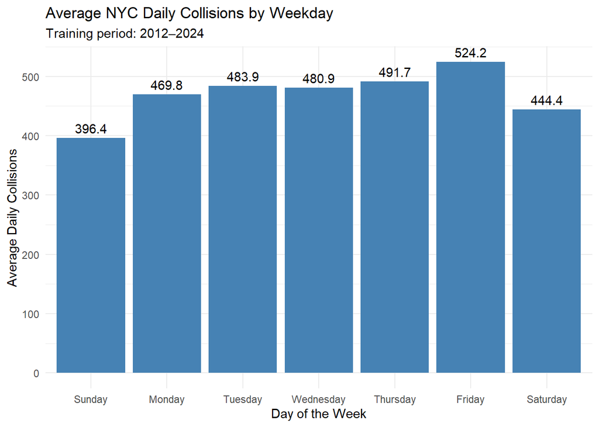

```r
weekday_avg <- train |>
  as_tibble() |>
  group_by(weekday) |>
  summarise(
    average_crashes = mean(crashes, na.rm = TRUE),
    .groups = "drop"
  )

weekday_chart <- ggplot(
  weekday_avg,
  aes(x = weekday, y = average_crashes)
) +
  geom_col(fill = "steelblue") +
  geom_text(
    aes(label = round(average_crashes, 1)),
    vjust = -0.5
  ) +
  labs(
    title = "Average NYC Daily Collisions by Weekday",
    subtitle = "Training period: 2012–2024",
    x = "Day of the Week",
    y = "Average Daily Collisions"
  ) +
  theme_minimal()

weekday_chart
```

#4.2 Weekdays Versus Weekends

```r
weekday_weekend <- train |>
  mutate(
    day_type = if_else(
      lubridate::wday(day, week_start = 1) <= 5,
      "Weekday",
      "Weekend"
    ),
    day_type = factor(
      day_type,
      levels = c("Weekday", "Weekend")
    )
  ) |>
  as_tibble() |>
  group_by(day_type) |>
  summarise(
    average_crashes = mean(crashes, na.rm = TRUE),
    total_crashes = sum(crashes, na.rm = TRUE),
    number_of_days = n(),
    .groups = "drop"
  )

# Display summary
weekday_weekend
```

```
## # A tibble: 2 × 4
##   day_type average_crashes total_crashes number_of_days
##   <fct>              <dbl>         <int>          <int>
## 1 Weekday             490.       1598679           3262
## 2 Weekend             420.        548549           1305
```

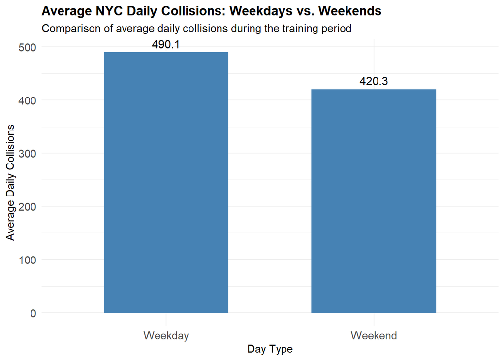

```r
weekday_weekend_chart <- ggplot(
  weekday_weekend,
  aes(x = day_type, y = average_crashes)
) +
  geom_col(
    fill = "steelblue",
    width = 0.6
  ) +
  geom_text(
    aes(label = round(average_crashes, 1)),
    vjust = -0.5,
    size = 4
  ) +
  labs(
    title = "Average NYC Daily Collisions: Weekdays vs. Weekends",
    subtitle = "Comparison of average daily collisions during the training period",
    x = "Day Type",
    y = "Average Daily Collisions"
  ) +
  theme_minimal() +
  theme(
    plot.title = element_text(face = "bold"),
    axis.text = element_text(size = 11)
  )

weekday_weekend_chart
```

```r
ggsave(
  "weekday_weekend_comparison.png",
  plot = weekday_weekend_chart,
  width = 9,
  height = 6,
  dpi = 300
)
```

#interpretation Weekdays Versus Weekends

The weekday-versus-weekend analysis examines differences in average daily motor vehicle collisions in New York City. Daily collision counts were grouped into weekdays (Monday through Friday) and weekends (Saturday and Sunday), and the average number of collisions was calculated for each group.

The comparison provides insight into how traffic activity and collision frequency vary across the weekly cycle. Differences between the two groups may reflect variations in commuting patterns, travel behavior, and recreational activity.

These findings support the inclusion of weekday effects in the time-series forecasting models, allowing the analysis to account for systematic differences in collision frequency across the days of the week.

#5. Stationarity and Time-Series Diagnostics Stationarity is important when developing ARIMA forecasting models. The analysis uses visual inspection, autocorrelation plots, and formal stationarity tests to investigate the characteristics of daily collision counts. #5.1 Time-Series Display

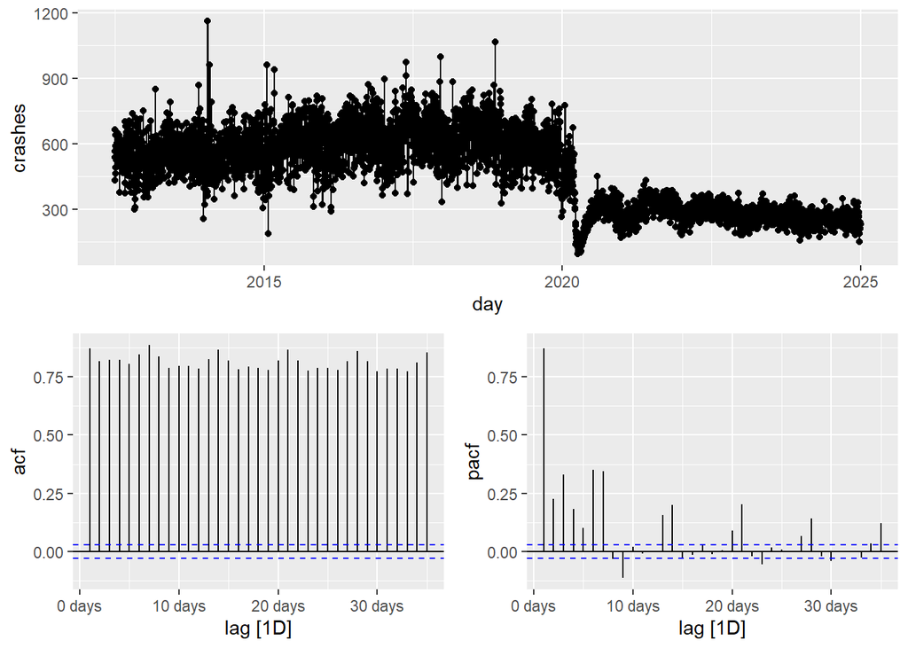

```r
train |>
  gg_tsdisplay(
    crashes,
    plot_type = "partial",
    lag_max = 35
  )
```

#5.2 KPSS Stationarity Test

```r
train |>
  features(
    crashes,
    unitroot_kpss
  )
```

```
## # A tibble: 1 × 2
##   kpss_stat kpss_pvalue
##       <dbl>       <dbl>
## 1      28.9        0.01
```

The KPSS test evaluates the null hypothesis that the series is stationary. A small p-value provides evidence against stationarity.

#5.3 Determine Differencing Requirements

```r
# Regular differencing
train |>
  features(
    crashes,
    unitroot_ndiffs
  )
```

```
## # A tibble: 1 × 1
##   ndiffs
##    <int>
## 1      1
```

```r
# Seasonal differencing
train |>
  features(
    crashes,
    unitroot_nsdiffs
  )
```

```
## # A tibble: 1 × 1
##   nsdiffs
##     <int>
## 1       0
```

The differencing recommendations help identify whether regular or seasonal differencing may be appropriate for ARIMA modeling.

#6. ETS Forecasting Models Exponential Smoothing models estimate the level, trend, and seasonal components of a time series.

This analysis evaluates an additive ETS specification and an automatically selected ETS model.

```r
  ets_models <- train |>
  model(
    ETS_Additive = ETS(
      crashes ~ error("A") +
        trend("A") +
        season("A")
    ),

    ETS_Automatic = ETS(crashes)
  )

# Model summaries
report(ets_models)
```

```
## # A tibble: 2 × 9
##   .model           sigma2 log_lik    AIC   AICc    BIC   MSE  AMSE     MAE
##   <chr>             <dbl>   <dbl>  <dbl>  <dbl>  <dbl> <dbl> <dbl>   <dbl>
## 1 ETS_Additive  3673.     -37981. 75987. 75987. 76064. 3664. 3976. 40.7
## 2 ETS_Automatic    0.0142 -37279. 74578. 74578. 74643. 3614. 3926.  0.0856
```

An additive ETS specification is used as a benchmark. The automatic ETS model selects an appropriate exponential smoothing structure based on the training data.

A multiplicative seasonal model can also be considered if the observations are strictly positive and the model is appropriate for the data.

#6.1 ETS Forecasts

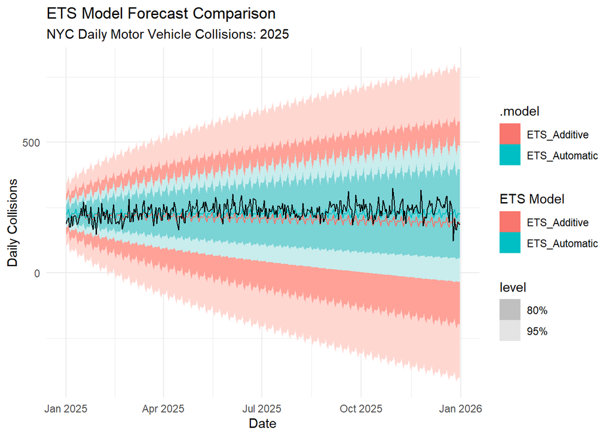

```r
ets_fc <- ets_models |>
  forecast(new_data = test)

autoplot(
  ets_fc,
  crash_ts |> filter_index("2025")
) +
  labs(
    title = "ETS Model Forecast Comparison",
    subtitle = "NYC Daily Motor Vehicle Collisions: 2025",
    x = "Date",
    y = "Daily Collisions",
    color = "ETS Model"
  ) +
  theme_minimal()
```

#6.2 ETS Accuracy

```r
ets_accuracy <- accuracy(
  ets_fc,
  test
) |>
  select(
    .model,
    RMSE,
    MAE,
    MAPE,
    MASE
  ) |>
  arrange(RMSE)

ets_accuracy
```

```
## # A tibble: 2 × 5
##   .model         RMSE   MAE  MAPE  MASE
##   <chr>         <dbl> <dbl> <dbl> <dbl>
## 1 ETS_Automatic  28.8  23.3  10.0   NaN
## 2 ETS_Additive   40.9  34.0  14.0   NaN
```

#7. ARIMA Forecasting ARIMA models capture temporal dependence through autoregressive, differencing, and moving-average components.

#7.1 Automatic ARIMA Model

```r
arima_auto <- train |>
  model(
    ARIMA_Automatic = ARIMA(crashes)
  )

report(arima_auto)
```

```
## Series: crashes
## Model: ARIMA(1,1,3)(0,0,2)[7]
##
## Coefficients:
##           ar1     ma1      ma2      ma3    sma1    sma2
##       -0.8647  0.2225  -0.8125  -0.2915  0.2913  0.1488
## s.e.   0.0267  0.0294   0.0201   0.0164  0.0158  0.0135
##
## sigma^2 estimated as 4659:  log likelihood=-25760.34
## AIC=51534.67   AICc=51534.7   BIC=51579.66
```

```r
tidy(arima_auto)
```

```
## # A tibble: 6 × 6
##   .model          term  estimate std.error statistic   p.value
##   <chr>           <chr>    <dbl>     <dbl>     <dbl>     <dbl>
## 1 ARIMA_Automatic ar1     -0.865    0.0267    -32.4  1.33e-207
## 2 ARIMA_Automatic ma1      0.222    0.0294      7.56 4.73e- 14
## 3 ARIMA_Automatic ma2     -0.812    0.0201    -40.4  1.46e-305
## 4 ARIMA_Automatic ma3     -0.291    0.0164    -17.8  9.59e- 69
## 5 ARIMA_Automatic sma1     0.291    0.0158     18.4  2.78e- 73
## 6 ARIMA_Automatic sma2     0.149    0.0135     11.0  6.08e- 28
```

Automatic ARIMA selection identifies a suitable model based on the training data.

#7.2 ARIMA Residual Diagnostics

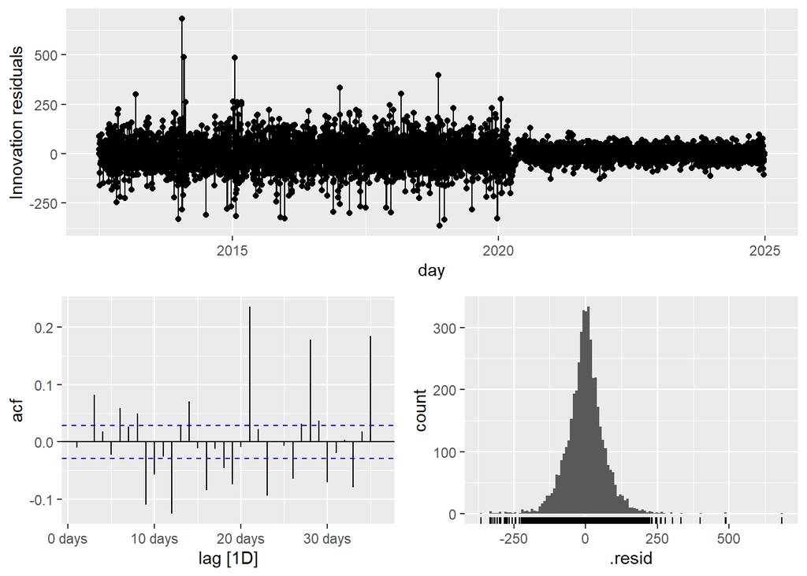

```r
arima_auto |>
  gg_tsresiduals()
```

```r
arima_auto |>
  augment() |>
  features(
    .innov,
    ljung_box,
    lag = 14,
    dof = 0
  )
```

```
## # A tibble: 1 × 3
##   .model          lb_stat lb_pvalue
##   <chr>             <dbl>     <dbl>
## 1 ARIMA_Automatic    238.         0
```

The Ljung-Box test evaluates whether residual autocorrelation remains. A small p-value suggests that the residuals contain additional temporal structure.

The degrees of freedom should be adjusted to reflect the estimated ARMA parameters when conducting the formal model-specific test. The value above is a conservative initial diagnostic, not a universal degrees-of-freedom choice.

#7.3 ARIMA Forecasts

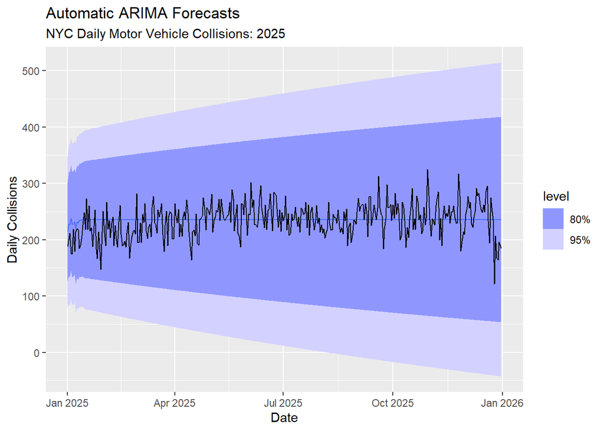

```r
arima_fc <- arima_auto |>
  forecast(new_data = test)

autoplot(
  arima_fc,
  crash_ts |> filter_index("2025")
) +
  labs(
    title = "Automatic ARIMA Forecasts",
    subtitle = "NYC Daily Motor Vehicle Collisions: 2025",
    x = "Date",
    y = "Daily Collisions"
  )
```

#7.4 ARIMA Accuracy

```r
arima_accuracy <- accuracy(
  arima_fc,
  test
) |>
  select(
    .model,
    RMSE,
    MAE,
    MAPE,
    MASE
  )

arima_accuracy
```

```
## # A tibble: 1 × 5
##   .model           RMSE   MAE  MAPE  MASE
##   <chr>           <dbl> <dbl> <dbl> <dbl>
## 1 ARIMA_Automatic  29.6  23.5  10.5   NaN
```

#8. ARIMAX Forecasting Model ARIMAX extends ARIMA by including explanatory variables. This analysis incorporates a linear trend, weekday indicators, and Fourier terms to represent annual seasonality.

Fourier terms are constructed using sine and cosine functions with an annual period of approximately 365.25 days.

#8.1 Create Fourier Variables

```r
train_x <- train |>
  mutate(
    fourier_1 = sin(2 * pi * trend / 365.25),
    fourier_2 = cos(2 * pi * trend / 365.25),
    fourier_3 = sin(4 * pi * trend / 365.25),
    fourier_4 = cos(4 * pi * trend / 365.25)
  )

test_x <- test |>
  mutate(
    fourier_1 = sin(2 * pi * trend / 365.25),
    fourier_2 = cos(2 * pi * trend / 365.25),
    fourier_3 = sin(4 * pi * trend / 365.25),
    fourier_4 = cos(4 * pi * trend / 365.25)
  )
```

#8.2 Fit ARIMAX

```r
arimax_model <- train_x |>
  model(
    ARIMAX = ARIMA(
      crashes ~ trend +
        weekday +
        fourier_1 +
        fourier_2 +
        fourier_3 +
        fourier_4
    )
  )

report(arimax_model)
```

```
## Series: crashes
## Model: LM w/ ARIMA(1,0,1)(2,0,0)[7] errors
##
## Coefficients:
##          ar1      ma1    sar1    sar2    trend  weekdayMonday  weekdayTuesday
##       0.9814  -0.7424  0.1155  0.0782  -0.0958        73.4225         87.6932
## s.e.  0.0039   0.0168  0.0152  0.0156   0.0118         3.8418          3.8886
##       weekdayWednesday  weekdayThursday  weekdayFriday  weekdaySaturday
##                84.2069          95.2070       127.7823          47.9989
## s.e.            3.9134           3.9134         3.8902           3.8435
##       fourier_1  fourier_2  fourier_3  fourier_4  intercept
##         15.9681    14.7257   -15.5295     2.9283   614.8648
## s.e.    16.7167    16.5150    10.7652    10.7079    31.3805
##
## sigma^2 estimated as 4007:  log likelihood=-25416.76
## AIC=50867.51   AICc=50867.65   BIC=50976.76
```

```r
tidy(arimax_model)
```

```
## # A tibble: 16 × 6
##    .model term             estimate std.error statistic   p.value
##    <chr>  <chr>               <dbl>     <dbl>     <dbl>     <dbl>
##  1 ARIMAX ar1                0.981    0.00386   254.    0
##  2 ARIMAX ma1               -0.742    0.0168    -44.1   0
##  3 ARIMAX sar1               0.116    0.0152      7.59  3.87e- 14
##  4 ARIMAX sar2               0.0782   0.0156      5.01  5.64e-  7
##  5 ARIMAX trend             -0.0958   0.0118     -8.12  5.81e- 16
##  6 ARIMAX weekdayMonday     73.4      3.84       19.1   2.16e- 78
##  7 ARIMAX weekdayTuesday    87.7      3.89       22.6   7.31e-107
##  8 ARIMAX weekdayWednesday  84.2      3.91       21.5   6.67e- 98
##  9 ARIMAX weekdayThursday   95.2      3.91       24.3   4.88e-123
## 10 ARIMAX weekdayFriday    128.       3.89       32.8   1.30e-212
## 11 ARIMAX weekdaySaturday   48.0      3.84       12.5   3.23e- 35
## 12 ARIMAX fourier_1         16.0     16.7         0.955 3.40e-  1
## 13 ARIMAX fourier_2         14.7     16.5         0.892 3.73e-  1
## 14 ARIMAX fourier_3        -15.5     10.8        -1.44  1.49e-  1
## 15 ARIMAX fourier_4          2.93    10.7         0.273 7.85e-  1
## 16 ARIMAX intercept        615.      31.4        19.6   3.79e- 82
```

#8.3 ARIMAX Residual Diagnostics

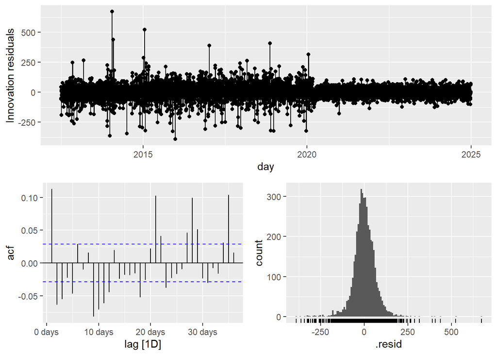

```r
arimax_model |>
  gg_tsresiduals()
```

```r
arimax_model |>
  augment() |>
  features(
    .innov,
    ljung_box,
    lag = 14,
    dof = 0
  )
```

```
## # A tibble: 1 × 3
##   .model lb_stat lb_pvalue
##   <chr>    <dbl>     <dbl>
## 1 ARIMAX    193.         0
```

As with the automatic ARIMA model, the degrees of freedom should be refined using the fitted ARIMA error structure.

#8.4 ARIMAX Forecasts

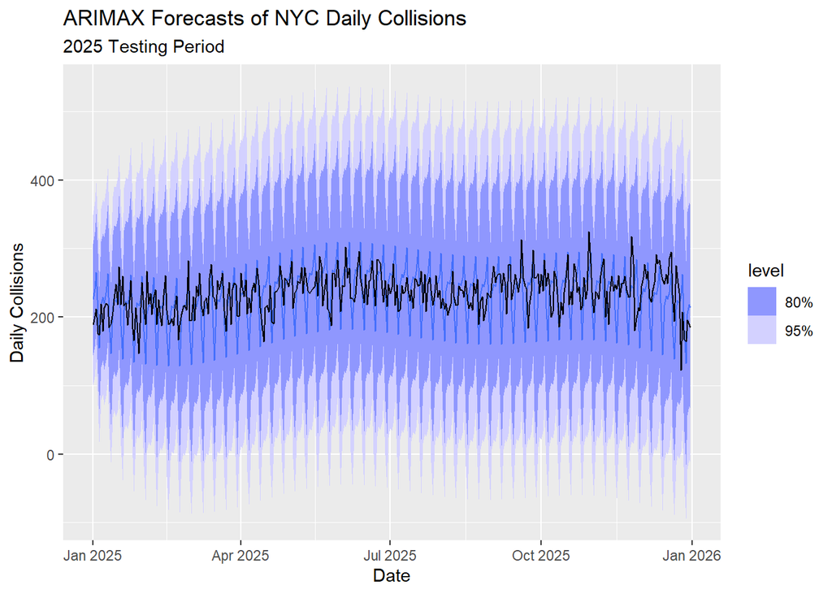

```r
arimax_fc <- arimax_model |>
  forecast(new_data = test_x)

autoplot(
  arimax_fc,
  crash_ts |> filter_index("2025")
) +
  labs(
    title = "ARIMAX Forecasts of NYC Daily Collisions",
    subtitle = "2025 Testing Period",
    x = "Date",
    y = "Daily Collisions"
  )
```

#8.5 ARIMAX Accuracy

```r
arimax_accuracy <- accuracy(
  arimax_fc,
  test
) |>
  select(
    .model,
    RMSE,
    MAE,
    MAPE,
    MASE
  )

arimax_accuracy
```

```
## # A tibble: 1 × 5
##   .model  RMSE   MAE  MAPE  MASE
##   <chr>  <dbl> <dbl> <dbl> <dbl>
## 1 ARIMAX  37.6  29.8  13.2   NaN
```

#9. TSLM Forecasting Models Time Series Linear Models provide an interpretable approach to modeling temporal trends and seasonal patterns.

Three specifications are evaluated.

#9.1 Trend-Only Model The first model incorporates a linear time trend to examine the overall direction of daily collision frequency.

```r
fit_trend <- train |>
  model(
    Trend_Only = TSLM(
      crashes ~ trend
    )
  )

report(fit_trend)
```

```
## Series: crashes
## Model: TSLM
##
## Residuals:
##     Min      1Q  Median      3Q     Max
## -410.34  -78.09  -22.22   78.09  599.13
##
## Coefficients:
##               Estimate Std. Error t value Pr(>|t|)
## (Intercept) 688.154235   3.670542  187.48   <2e-16 ***
## trend        -0.095443   0.001392  -68.57   <2e-16 ***
## ---
## Signif. codes:  0 '***' 0.001 '**' 0.01 '*' 0.05 '.' 0.1 ' ' 1
##
## Residual standard error: 124 on 4565 degrees of freedom
## Multiple R-squared: 0.5074,  Adjusted R-squared: 0.5073
## F-statistic:  4702 on 1 and 4565 DF, p-value: < 2.22e-16
```

#Residual Diagnostics

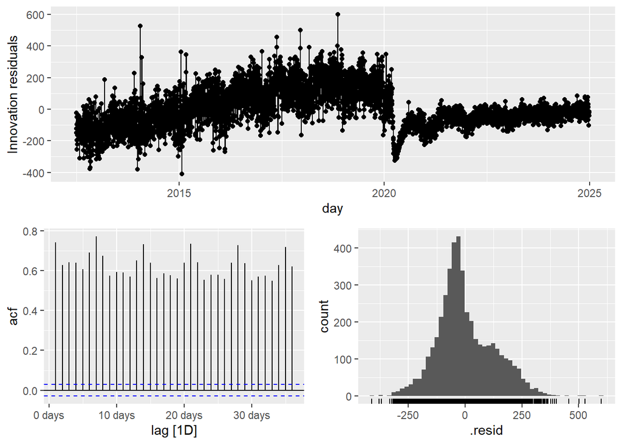

```r
fit_trend |>
  gg_tsresiduals()
```

#Forecasts

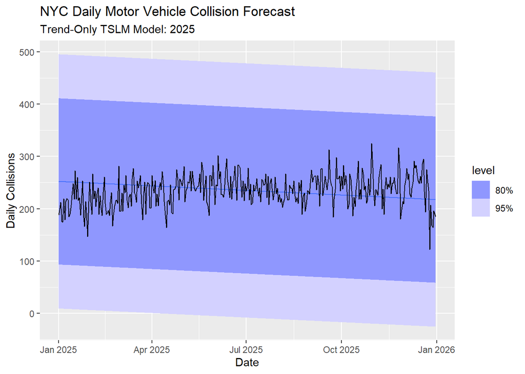

```r
forecast_trend <- fit_trend |>
  forecast(new_data = test)

autoplot(
  forecast_trend,
  crash_ts |> filter_index("2025")
) +
  labs(
    title = "NYC Daily Motor Vehicle Collision Forecast",
    subtitle = "Trend-Only TSLM Model: 2025",
    x = "Date",
    y = "Daily Collisions"
  )
```

#Accuracy

```r
accuracy_trend <- accuracy(
  forecast_trend,
  test
)

accuracy_trend
```

```
## # A tibble: 1 × 10
##   .model     .type     ME  RMSE   MAE   MPE  MAPE  MASE RMSSE  ACF1
##   <chr>      <chr>  <dbl> <dbl> <dbl> <dbl> <dbl> <dbl> <dbl> <dbl>
## 1 Trend_Only Test  -0.390  33.9  27.1 -2.06  12.0   NaN   NaN 0.505
```

#9.2 Trend and Weekly Seasonality Model The second specification incorporates weekday indicators to capture differences in collision frequency across the seven days of the week.

```r
fit_trend_seasonal <- train |>
  model(
    Trend_Weekly = TSLM(
      crashes ~ trend + weekday
    )
  )

report(fit_trend_seasonal)
```

```
## Series: crashes
## Model: TSLM
##
## Residuals:
##     Min      1Q  Median      3Q     Max
## -424.19  -79.00  -19.65   82.58  577.64
##
## Coefficients:
##                    Estimate Std. Error t value Pr(>|t|)
## (Intercept)      614.277127   5.533351 111.014  < 2e-16 ***
## trend             -0.095447   0.001328 -71.888  < 2e-16 ***
## weekdayMonday     73.496673   6.546719  11.226  < 2e-16 ***
## weekdayTuesday    87.731477   6.546719  13.401  < 2e-16 ***
## weekdayWednesday  84.491188   6.549228  12.901  < 2e-16 ***
## weekdayThursday   95.376513   6.549228  14.563  < 2e-16 ***
## weekdayFriday    127.979629   6.549229  19.541  < 2e-16 ***
## weekdaySaturday   48.222316   6.549229   7.363 2.12e-13 ***
## ---
## Signif. codes:  0 '***' 0.001 '**' 0.01 '*' 0.05 '.' 0.1 ' ' 1
##
## Residual standard error: 118.3 on 4559 degrees of freedom
## Multiple R-squared: 0.5523,  Adjusted R-squared: 0.5516
## F-statistic: 803.6 on 7 and 4559 DF, p-value: < 2.22e-16
```

#Residual Diagnostics

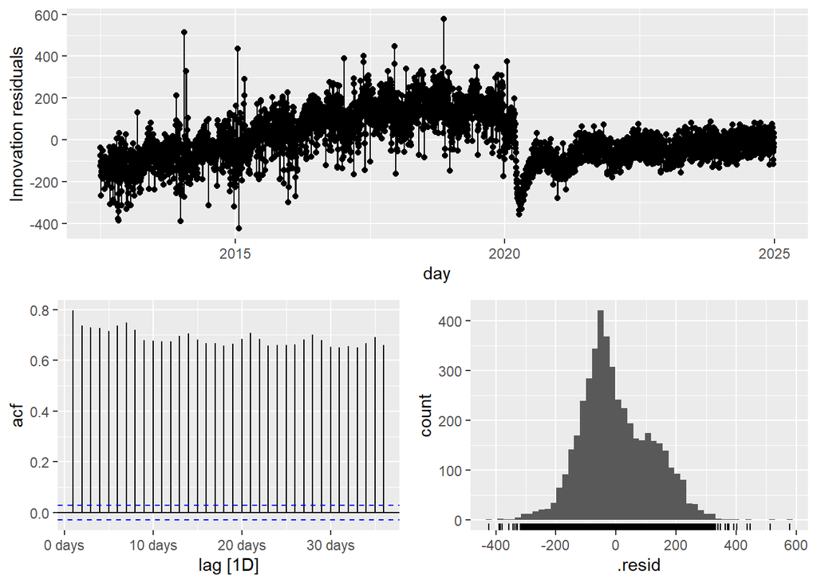

```r
fit_trend_seasonal |>
  gg_tsresiduals()
```

#Forecasts

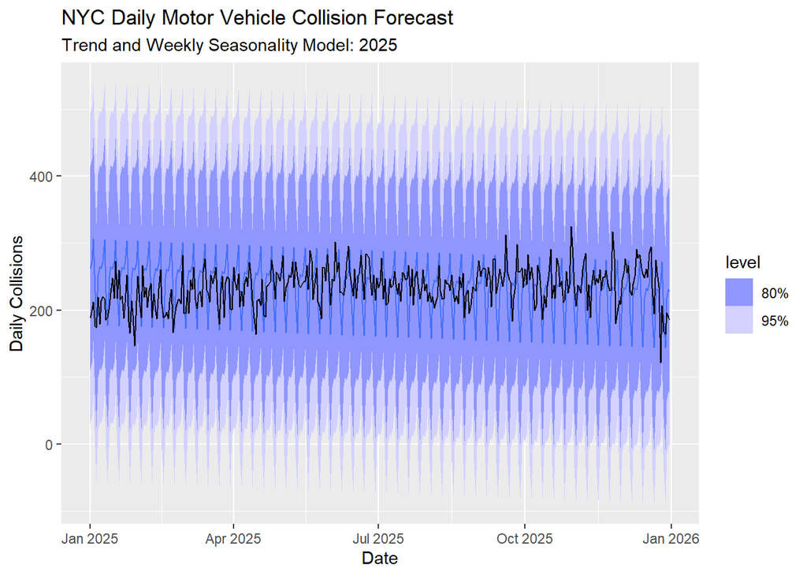

```r
forecast_seasonal <- fit_trend_seasonal |>
  forecast(new_data = test)

autoplot(
  forecast_seasonal,
  crash_ts |> filter_index("2025")
) +
  labs(
    title = "NYC Daily Motor Vehicle Collision Forecast",
    subtitle = "Trend and Weekly Seasonality Model: 2025",
    x = "Date",
    y = "Daily Collisions"
  )
```

#Accuracy

```r
accuracy_seasonal <- accuracy(
  forecast_seasonal,
  test
)

accuracy_seasonal
```

```
## # A tibble: 1 × 10
##   .model       .type     ME  RMSE   MAE   MPE  MAPE  MASE RMSSE  ACF1
##   <chr>        <chr>  <dbl> <dbl> <dbl> <dbl> <dbl> <dbl> <dbl> <dbl>
## 1 Trend_Weekly Test  -0.422  42.0  33.9 -1.35  15.1   NaN   NaN 0.416
```

#9.3 Full TSLM: Trend, Weekly and Annual Seasonality The third model incorporates both weekday indicators and annual Fourier terms.

```r
fit_tslm_full <- train |>
  model(
    TSLM_Full = TSLM(
      crashes ~ trend +
        weekday +
        fourier(
          K = 5,
          period = 365.25
        )
    )
  )

report(fit_tslm_full)
```

```
## Series: crashes
## Model: TSLM
##
## Residuals:
##     Min      1Q  Median      3Q     Max
## -403.91  -79.63  -20.05   83.48  556.93
##
## Coefficients:
##                                         Estimate Std. Error t value Pr(>|t|)
## (Intercept)                           614.641975   5.442203 112.940  < 2e-16
## trend                                  -0.095768   0.001306 -73.312  < 2e-16
## weekdayMonday                          73.509440   6.437221  11.419  < 2e-16
## weekdayTuesday                         87.757110   6.437222  13.633  < 2e-16
## weekdayWednesday                       84.481068   6.439690  13.119  < 2e-16
## weekdayThursday                        95.377247   6.439690  14.811  < 2e-16
## weekdayFriday                         127.991365   6.439691  19.875  < 2e-16
## weekdaySaturday                        48.245187   6.439693   7.492 8.11e-14
## fourier(K = 5, period = 365.25)C1_365 -15.274287   2.435371  -6.272 3.90e-10
## fourier(K = 5, period = 365.25)S1_365 -15.297136   2.436418  -6.279 3.74e-10
## fourier(K = 5, period = 365.25)C2_365   1.831252   2.435410   0.752 0.452133
## fourier(K = 5, period = 365.25)S2_365 -15.674569   2.437591  -6.430 1.40e-10
## fourier(K = 5, period = 365.25)C3_365  -9.153248   2.435282  -3.759 0.000173
## fourier(K = 5, period = 365.25)S3_365   7.324778   2.436363   3.006 0.002658
## fourier(K = 5, period = 365.25)C4_365  -6.576940   2.435316  -2.701 0.006946
## fourier(K = 5, period = 365.25)S4_365  -9.622764   2.436642  -3.949 7.96e-05
## fourier(K = 5, period = 365.25)C5_365  -1.151295   2.434407  -0.473 0.636288
## fourier(K = 5, period = 365.25)S5_365  -4.382161   2.435678  -1.799 0.072061
##
## (Intercept)                           ***
## trend                                 ***
## weekdayMonday                         ***
## weekdayTuesday                        ***
## weekdayWednesday                      ***
## weekdayThursday                       ***
## weekdayFriday                         ***
## weekdaySaturday                       ***
## fourier(K = 5, period = 365.25)C1_365 ***
## fourier(K = 5, period = 365.25)S1_365 ***
## fourier(K = 5, period = 365.25)C2_365
## fourier(K = 5, period = 365.25)S2_365 ***
## fourier(K = 5, period = 365.25)C3_365 ***
## fourier(K = 5, period = 365.25)S3_365 **
## fourier(K = 5, period = 365.25)C4_365 **
## fourier(K = 5, period = 365.25)S4_365 ***
## fourier(K = 5, period = 365.25)C5_365
## fourier(K = 5, period = 365.25)S5_365 .
## ---
## Signif. codes:  0 '***' 0.001 '**' 0.01 '*' 0.05 '.' 0.1 ' ' 1
##
## Residual standard error: 116.3 on 4549 degrees of freedom
## Multiple R-squared: 0.5681,  Adjusted R-squared: 0.5665
## F-statistic:   352 on 17 and 4549 DF, p-value: < 2.22e-16
```

#Residual Diagnostics

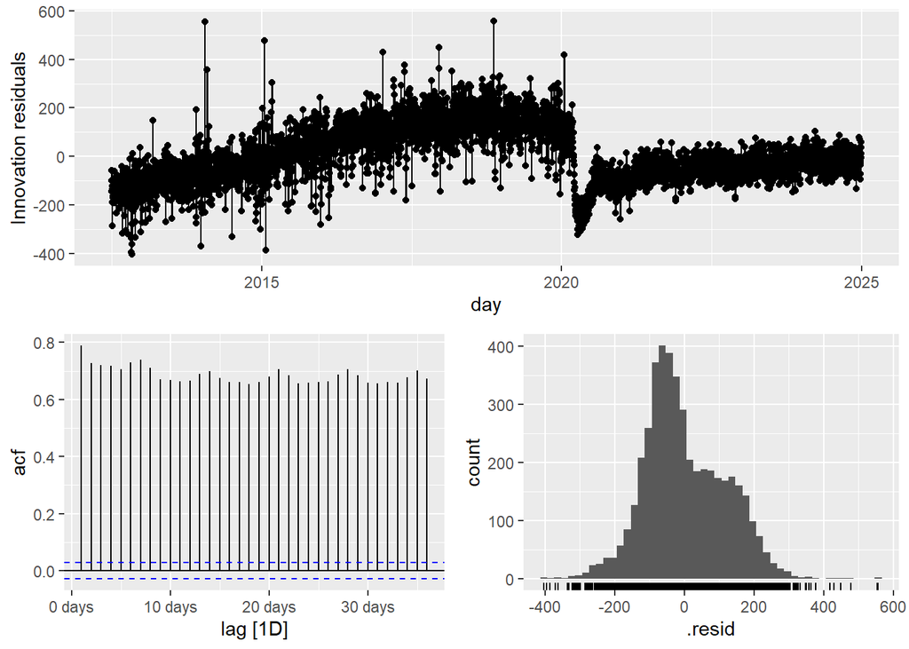

```r
fit_tslm_full |>
  gg_tsresiduals()
```

#Forecasts

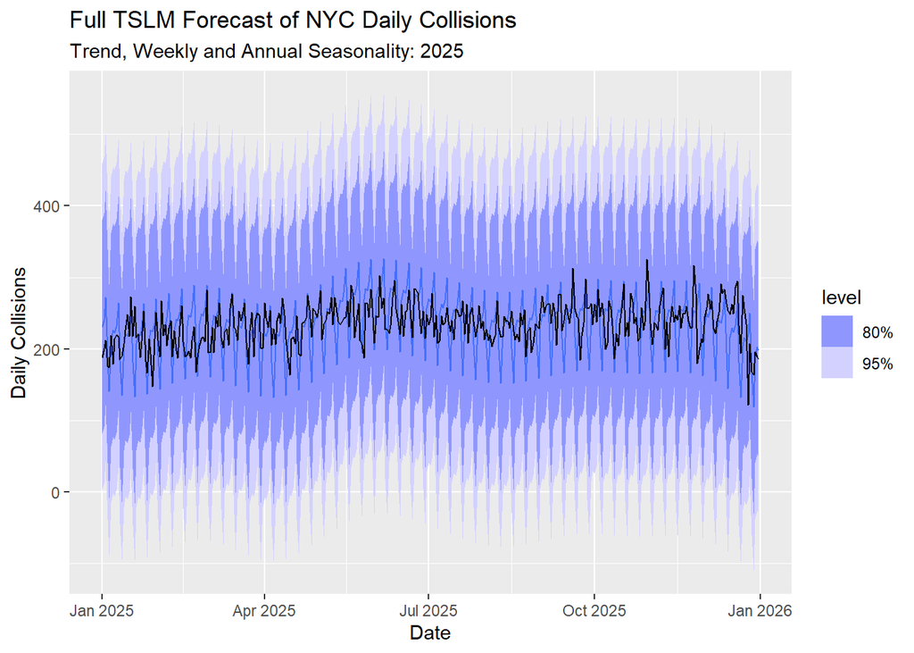

```r
forecast_tslm_full <- fit_tslm_full |>
  forecast(new_data = test)

autoplot(
  forecast_tslm_full,
  crash_ts |> filter_index("2025")
) +
  labs(
    title = "Full TSLM Forecast of NYC Daily Collisions",
    subtitle = "Trend, Weekly and Annual Seasonality: 2025",
    x = "Date",
    y = "Daily Collisions"
  )
```

#Accuracy

```r
accuracy_tslm_full <- accuracy(
  forecast_tslm_full,
  test
)

accuracy_tslm_full
```

```
## # A tibble: 1 × 10
##   .model    .type    ME  RMSE   MAE    MPE  MAPE  MASE RMSSE  ACF1
##   <chr>     <chr> <dbl> <dbl> <dbl>  <dbl> <dbl> <dbl> <dbl> <dbl>
## 1 TSLM_Full Test  0.708  38.5  30.1 -0.340  13.4   NaN   NaN 0.308
```

#10. Model Comparison All forecasting models are evaluated using the same testing period. This provides a consistent basis for comparing their predictive performance.

#10.1 Fit the Benchmark Models The seasonal naïve model provides a useful benchmark by repeating the previous week’s observations.

```r
fits <- train |>
  model(
    Seasonal_Naive = SNAIVE(
      crashes ~ lag("week")
    ),

    ETS_Additive = ETS(
      crashes ~ error("A") +
        trend("A") +
        season("A")
    ),

    ETS_Automatic = ETS(crashes),

    ARIMA_Automatic = ARIMA(crashes),

    ARIMAX = ARIMA(
      crashes ~ trend +
        weekday +
        fourier(
          K = 5,
          period = 365.25
        )
    ),

    TSLM_Full = TSLM(
      crashes ~ trend +
        weekday +
        fourier(
          K = 5,
          period = 365.25
        )
    )
  )

report(fits)
```

```
## # A tibble: 6 × 20
##   .model        sigma2 log_lik    AIC   AICc    BIC   MSE  AMSE     MAE ar_roots
##   <chr>          <dbl>   <dbl>  <dbl>  <dbl>  <dbl> <dbl> <dbl>   <dbl> <list>
## 1 Seasonal_Na… 7.02e+3     NA     NA     NA     NA    NA    NA  NA      <NULL>
## 2 ETS_Additive 3.67e+3 -37981. 75987. 75987. 76064. 3664. 3976. 40.7    <NULL>
## 3 ETS_Automat… 1.42e-2 -37279. 74578. 74578. 74643. 3614. 3926.  0.0856 <NULL>
## 4 ARIMA_Autom… 4.66e+3 -25760. 51535. 51535. 51580.   NA    NA  NA      <cpl>
## 5 ARIMAX       4.01e+3 -25413. 50872. 50873. 51020.   NA    NA  NA      <cpl>
## 6 TSLM_Full    1.35e+4 -28193. 43464. 43464. 43586.   NA    NA  NA      <NULL>
## # ℹ 10 more variables: ma_roots <list>, r_squared <dbl>, adj_r_squared <dbl>,
## #   statistic <dbl>, p_value <dbl>, df <int>, CV <dbl>, deviance <dbl>,
## #   df.residual <int>, rank <int>
```

#10.2 Generate Forecasts

```r
fc <- fits |>
  forecast(new_data = test)

fc
```

```
## # A fable: 2,190 x 6 [1D]
## # Key:     .model [6]
##    .model         day
##    <chr>          <date>
##  1 Seasonal_Naive 2025-01-01
##  2 Seasonal_Naive 2025-01-02
##  3 Seasonal_Naive 2025-01-03
##  4 Seasonal_Naive 2025-01-04
##  5 Seasonal_Naive 2025-01-05
##  6 Seasonal_Naive 2025-01-06
##  7 Seasonal_Naive 2025-01-07
##  8 Seasonal_Naive 2025-01-08
##  9 Seasonal_Naive 2025-01-09
## 10 Seasonal_Naive 2025-01-10
## # ℹ 2,180 more rows
## # ℹ 4 more variables: crashes <dist>, .mean <dbl>, trend <int>, weekday <fct>
```

#10.3 Calculate Forecast Accuracy

```r
final_accuracy <- accuracy(
  fc,
  test
) |>
  select(
    .model,
    RMSE,
    MAE,
    MAPE,
    MASE,
    ACF1
  ) |>
  arrange(RMSE)

final_accuracy
```

```
## # A tibble: 6 × 6
##   .model           RMSE   MAE  MAPE  MASE  ACF1
##   <chr>           <dbl> <dbl> <dbl> <dbl> <dbl>
## 1 ETS_Automatic    28.8  23.3  10.0   NaN 0.385
## 2 ARIMA_Automatic  29.6  23.5  10.5   NaN 0.351
## 3 ARIMAX           38.2  29.9  13.3   NaN 0.302
## 4 TSLM_Full        38.5  30.1  13.4   NaN 0.308
## 5 ETS_Additive     40.9  34.0  14.0   NaN 0.536
## 6 Seasonal_Naive   46.6  35.5  14.9   NaN 0.143
```

Lower RMSE, MAE, MAPE, and MASE values indicate better forecasting performance. ACF1 provides information about first-order residual autocorrelation.

#10.4 Identify the Best Forecasting Model

```r
best_model <- final_accuracy |>
  slice_min(
    RMSE,
    n = 1,
    with_ties = FALSE
  )

best_model
```

```
## # A tibble: 1 × 6
##   .model         RMSE   MAE  MAPE  MASE  ACF1
##   <chr>         <dbl> <dbl> <dbl> <dbl> <dbl>
## 1 ETS_Automatic  28.8  23.3  10.0   NaN 0.385
```

Model selection should consider forecast accuracy alongside residual diagnostics and model interpretability.

#10.5 Plot Forecast Comparisons

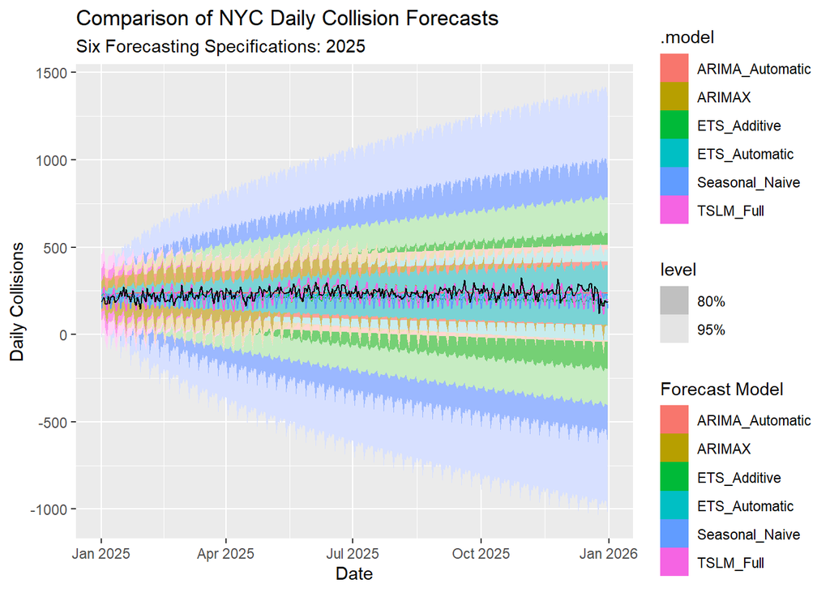

```r
autoplot(
  fc,
  crash_ts |> filter_index("2025")
) +
  labs(
    title = "Comparison of NYC Daily Collision Forecasts",
    subtitle = "Six Forecasting Specifications: 2025",
    x = "Date",
    y = "Daily Collisions",
    color = "Forecast Model"
  )
```

#11. TSLM Model Explanatory Power R-squared measures the proportion of variation explained by a fitted regression model. It is an in-sample measure and should not be confused with out-of-sample forecast accuracy.

```r
glance(fit_trend)
```

```
## # A tibble: 1 × 15
##   .model   r_squared adj_r_squared sigma2 statistic p_value    df log_lik    AIC
##   <chr>        <dbl>         <dbl>  <dbl>     <dbl>   <dbl> <int>   <dbl>  <dbl>
## 1 Trend_O…     0.507         0.507 15378.     4702.       0     2 -28494. 44033.
## # ℹ 6 more variables: AICc <dbl>, BIC <dbl>, CV <dbl>, deviance <dbl>,
## #   df.residual <int>, rank <int>
```

```r
glance(fit_trend_seasonal)
```

```
## # A tibble: 1 × 15
##   .model   r_squared adj_r_squared sigma2 statistic p_value    df log_lik    AIC
##   <chr>        <dbl>         <dbl>  <dbl>     <dbl>   <dbl> <int>   <dbl>  <dbl>
## 1 Trend_W…     0.552         0.552 13994.      804.       0     8 -28275. 43608.
## # ℹ 6 more variables: AICc <dbl>, BIC <dbl>, CV <dbl>, deviance <dbl>,
## #   df.residual <int>, rank <int>
```

```r
glance(fit_tslm_full)
```

```
## # A tibble: 1 × 15
##   .model   r_squared adj_r_squared sigma2 statistic p_value    df log_lik    AIC
##   <chr>        <dbl>         <dbl>  <dbl>     <dbl>   <dbl> <int>   <dbl>  <dbl>
## 1 TSLM_Fu…     0.568         0.567 13529.      352.       0    18 -28193. 43464.
## # ℹ 6 more variables: AICc <dbl>, BIC <dbl>, CV <dbl>, deviance <dbl>,
## #   df.residual <int>, rank <int>
```

#12. Road-User Injury Analysis In addition to collision frequency, the original dataset contains injury information for pedestrians, cyclists, and motor vehicle occupants.

The following section aggregates daily injury counts separately for each road-user group.

```r
road_user_daily <- crashes |>
  group_by(day) |>
  summarise(
    ped_injured = sum(
      number_of_pedestrians_injured,
      na.rm = TRUE
    ),
    cyc_injured = sum(
      number_of_cyclist_injured,
      na.rm = TRUE
    ),
    mot_injured = sum(
      number_of_motorist_injured,
      na.rm = TRUE
    ),
    .groups = "drop"
  )
```

#12.1 Road-User Injury Time Series

```r
# Aggregate daily injuries by road-user category

road_user_daily <- crashes |>
  group_by(day) |>
  summarise(
    ped_injured = sum(
      number_of_pedestrians_injured,
      na.rm = TRUE
    ),
    cyc_injured = sum(
      number_of_cyclist_injured,
      na.rm = TRUE
    ),
    mot_injured = sum(
      number_of_motorist_injured,
      na.rm = TRUE
    ),
    .groups = "drop"
  )
```

This analysis provides additional context about the distribution of traffic-related injuries across road-user groups. Collision counts and injury counts represent different outcomes and should be interpreted separately.

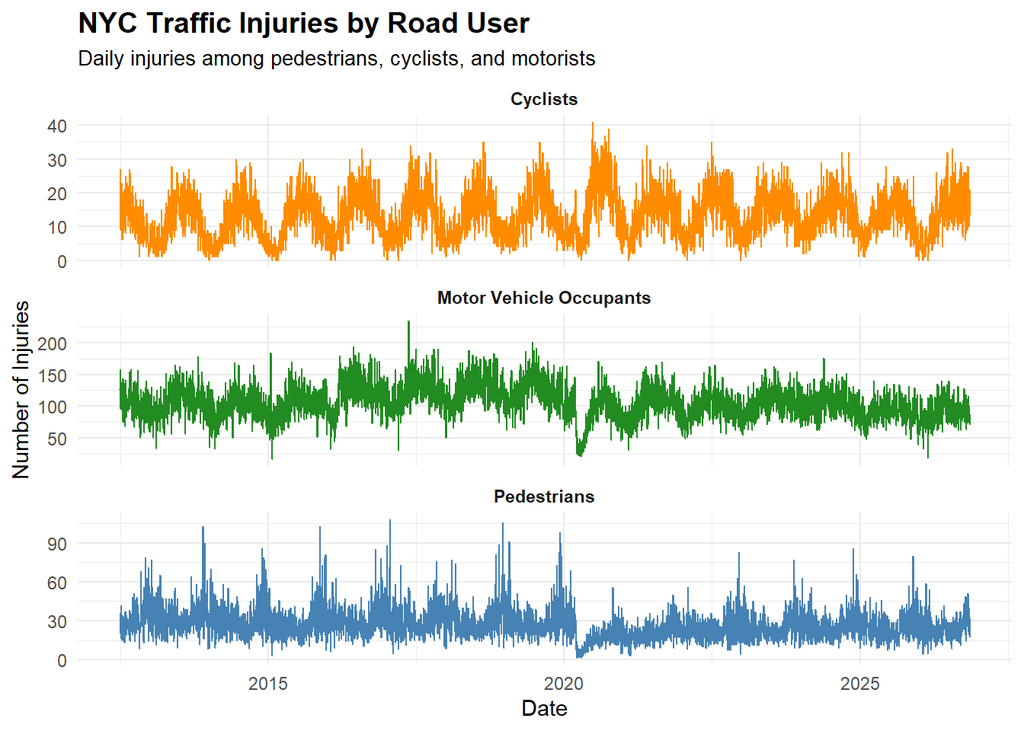

```r
road_user_chart <- road_user_daily |>
  pivot_longer(
    cols = c(
      ped_injured,
      cyc_injured,
      mot_injured
    ),
    names_to = "road_user",
    values_to = "injuries"
  ) |>
  mutate(
    road_user = recode(
      road_user,
      ped_injured = "Pedestrians",
      cyc_injured = "Cyclists",
      mot_injured = "Motor Vehicle Occupants"
    )
  ) |>
  ggplot(
    aes(
      x = day,
      y = injuries,
      color = road_user
    )
  ) +
  geom_line(linewidth = 0.5) +
  facet_wrap(
    ~road_user,
    scales = "free_y",
    ncol = 1
  ) +
  scale_color_manual(
    values = c(
      "Pedestrians" = "steelblue",
      "Cyclists" = "darkorange",
      "Motor Vehicle Occupants" = "forestgreen"
    )
  ) +
  labs(
    title = "NYC Traffic Injuries by Road User",
    subtitle = "Daily injuries among pedestrians, cyclists, and motorists",
    x = "Date",
    y = "Number of Injuries",
    color = "Road User"
  ) +
  theme_minimal() +
  theme(
    plot.title = element_text(
      face = "bold",
      size = 14
    ),
    plot.subtitle = element_text(size = 10),
    strip.text = element_text(face = "bold"),
    legend.position = "none"
  )

road_user_chart
```

```r
road_user_summary <- road_user_daily |>
  summarise(
    Pedestrians = sum(ped_injured, na.rm = TRUE),
    Cyclists = sum(cyc_injured, na.rm = TRUE),
    Motorists = sum(mot_injured, na.rm = TRUE)
  ) |>
  pivot_longer(
    everything(),
    names_to = "Road_User",
    values_to = "Total_Injuries"
  ) |>
  arrange(desc(Total_Injuries))

# Display results
road_user_summary
```

```
## # A tibble: 3 × 2
##   Road_User   Total_Injuries
##   <chr>                <dbl>
## 1 Motorists           553385
## 2 Pedestrians         141606
## 3 Cyclists             68863
```

#13. Export Figures The following code exports the principal visualizations in high resolution

```r
# Define output folder
output_folder <- "C:/Users/newer/OneDrive/Desktop/ADS506_Plots"

# Create folder if it does not exist
dir.create(
  output_folder,
  recursive = TRUE,
  showWarnings = FALSE
)

# Save weekday average chart
ggsave(
  filename = file.path(output_folder, "weekday_average.png"),
  plot = weekday_chart,
  width = 9,
  height = 6,
  dpi = 300
)

# Save weekday versus weekend chart
ggsave(
  filename = file.path(output_folder, "weekday_weekend.png"),
  plot = weekday_weekend_chart,
  width = 9,
  height = 6,
  dpi = 300
)

# Save road-user injury chart
ggsave(
  filename = file.path(output_folder, "road_user_injuries.png"),
  plot = road_user_chart,
  width = 12,
  height = 8,
  dpi = 300
)

# Confirm saved files
list.files(
  output_folder,
  pattern = "\\.png$",
  full.names = TRUE
)
```

```
## [1] "C:/Users/newer/OneDrive/Desktop/ADS506_Plots/acf and pacf plots.png"
## [2] "C:/Users/newer/OneDrive/Desktop/ADS506_Plots/road_user_injuries.png"
## [3] "C:/Users/newer/OneDrive/Desktop/ADS506_Plots/Seasonal_Forecast.png"
## [4] "C:/Users/newer/OneDrive/Desktop/ADS506_Plots/Seasonal_Residuals.png"
## [5] "C:/Users/newer/OneDrive/Desktop/ADS506_Plots/traffic_injuries_by_road_user.png"
## [6] "C:/Users/newer/OneDrive/Desktop/ADS506_Plots/Trend_Forecast.png"
## [7] "C:/Users/newer/OneDrive/Desktop/ADS506_Plots/Trend_Residuals.png"
## [8] "C:/Users/newer/OneDrive/Desktop/ADS506_Plots/weekday_average.png"
## [9] "C:/Users/newer/OneDrive/Desktop/ADS506_Plots/weekday_weekend.png"
```

#14. Conclusion This analysis examines daily motor vehicle collisions in New York City using historical observations beginning in 2012. The forecasting framework evaluates several statistical approaches, including Seasonal Naïve, ETS, ARIMA, ARIMAX, and TSLM.

The TSLM specifications progressively incorporate a linear trend, weekday indicators, and annual Fourier terms. This allows the analysis to examine the contribution of long-term changes and recurring seasonal patterns to daily collision frequency.

The final model selection should be based on the actual out-of-sample accuracy results and residual behavior rather than in-sample R-squared alone.

The road-user injury analysis provides an additional perspective by examining differences in injury patterns among pedestrians, cyclists, and motor vehicle occupants.

Overall, the project provides a structured framework for understanding historical collision patterns and evaluating statistical forecasting approaches. The findings may help inform further research into urban traffic safety, temporal collision patterns, and the distribution of traffic-related injuries.